# FPCC II - Lab 3, Checkpoint 1

Amanda Souza

17/05/2018

# Inferência Estatística: Discovery Hiring Analyst 2016

### Sumário

1. Introdução
2. Respondendo as perguntas por meio de ICs
3. Conclusão

### 1) Introdução

Os dados analisados neste relatório podem ser melhor explorados no [Rpubs](http://rpubs.com/aminueza/DiscoveryHiringAnalyst2016) do laboratório anterior, provenientes de um modelo de rastreamento que a [Wikimedia Foundation](https://grafana.wikimedia.org/dashboard/db/eventlogging-schema) usa para avaliar o nível de satisfação do usuário. A proposta desse relatório é verificar as mesmas variáveis usando inferência estatística.

### 2) Respondendo as perguntas por meio de ICs

**1. What is our daily overall clickthrough rate? How does it vary between the groups?**

Primeiro é preciso tratar os dados, filtrando os eventos com sessões únicas e agrupando por data. Por fim, é necessário filtrar os dados que apresentam uma Página de Retorno do Motor de Busca (SERP) associada a sessão.

```r
#Removendo sessões duplicadas
wikimediad = wikimedia %>%
    distinct(session_id, .keep_all = T)

#Agrupando por dia
wikimediad = wikimediad %>%
  mutate(session_start_date = round_date(session_start_date, unit = "day"))

#Calculando CRT
wikimediad <- wikimediad %>%
  filter(results >= first_click | (!is.na(num_clicks) & num_clicks == 0))
```

Após o tratamento, vamos usar o bootstrap para realizar uma amostra da população e inferir onde está a média de `crt` *na população* com uma confiança de 95%. Também, vamos analisar a distribuição dos Intervalos de Confiança dessas amostras:

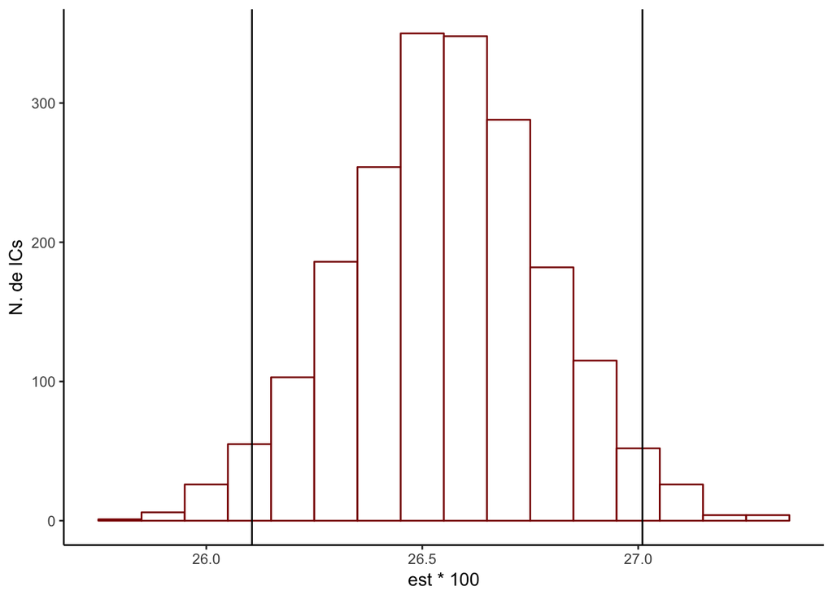

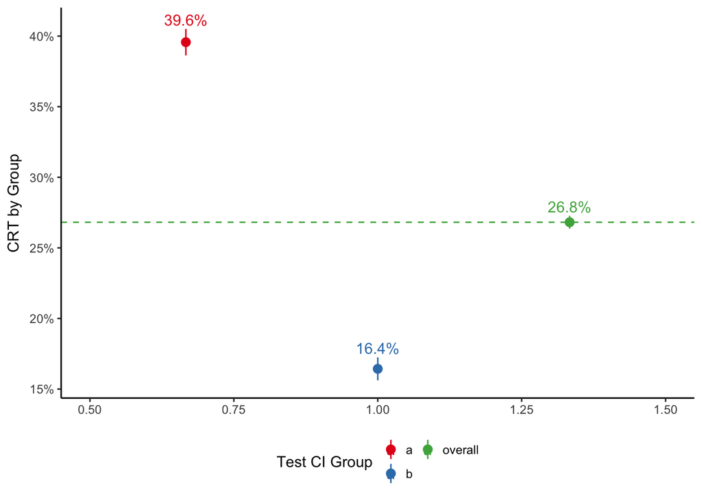

O gráfico dos intervalos de Confiança da taxa de cliques mostra que o grupo A apresenta uma significativa diferença maior que o grupo B. O intervalo de confiança do grupo A foi de 38.64% a 40.50% e do grupo B foi de 15.59% a 17.27%. Assim, a taxa de cliques do grupo A é maior do que o grupo B. Em relação a taxa total, é possível visualizar que o grupo A possui uma taxa de cliques maior que a taxa total, concluindo que a taxa de cliques do grupo A é maior que a taxa de cliques média por dia.

**2. Which results do people tend to try first? How does it change day-to-day?**

Primeiro, vamos limpar os dados e clacular o intervalo de confiança:

O intervalo de confiança para todos os cliques por dia foi negativo e ficou entre -997.0 e -534.1 Isso representa que a média do primeiro clique é subtraída da média do segundo clique, e com uma diferença negativa significa que a média do primeiro clique é maior que a média do segundo clique.

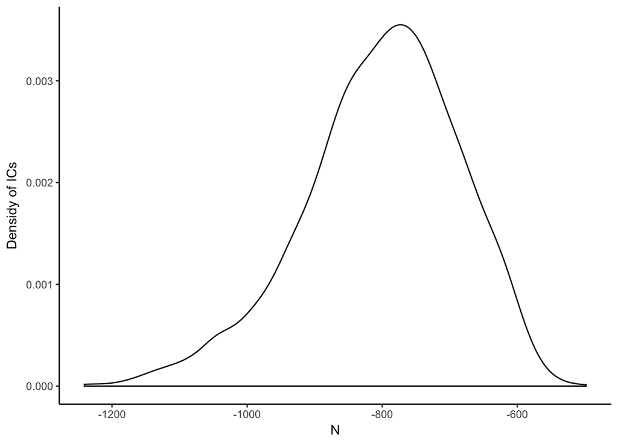

Para confirmar a hipótese sobre o primeiro clique ser maior que o segundo clique, calcularemos os intervalos de confiança para cada clique nos resultados, verificando a sua quantidade de cliques:

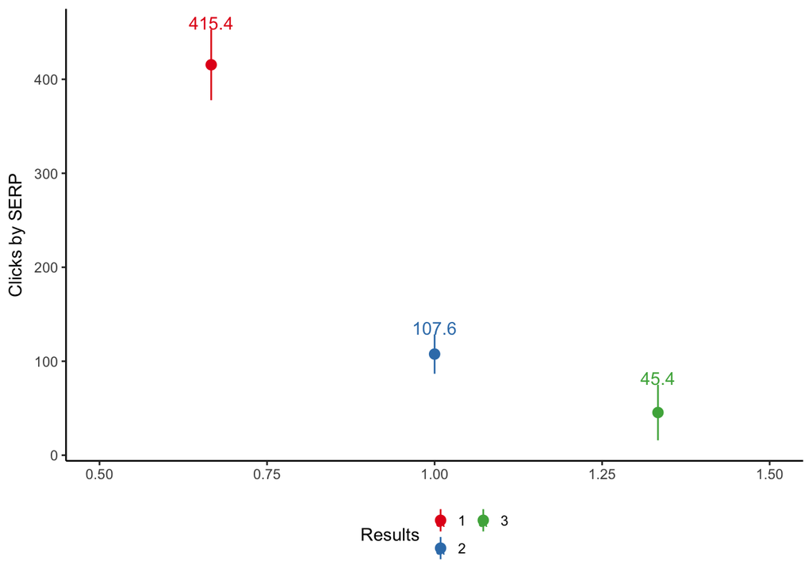

Pode-se notar que a página mais clicada frequente apresentam-se no primeiro resultado listado e o número de cliques no restante dos resultados cai com redução da classificação da listagem.

**3. What is our daily overall zero results rate? How does it vary between the groups?**

Primeiro, é necessário fazer a manipulação dos dados e calcular o intevalo de confiança total:

```r
zero_results <- function(dados, indices) {
  zero =  dados %>%
  slice(indices) %>%
  group_by(session_start_date) %>%
  summarise(zero = sum(results == 0),
            total = n()) %>%
  mutate(rate = zero/total * 100) %>%
  pull(median(rate))

  return(zero)
}

bootstraps_zero <- boot(data = wikimediad,
                   statistic = zero_results,
                   R = 2000) # número de bootstraps

boot.ci(bootstraps_zero, conf = 0.95, type = "basic")
```

```
## BOOTSTRAP CONFIDENCE INTERVAL CALCULATIONS
## Based on 2000 bootstrap replicates
##
## CALL :
## boot.ci(boot.out = bootstraps_zero, conf = 0.95, type = "basic")
##
## Intervals :
## Level      Basic
## 95%   (15.94, 18.50 )
## Calculations and Intervals on Original Scale
```

Analisando os ICs no histograma, temos:

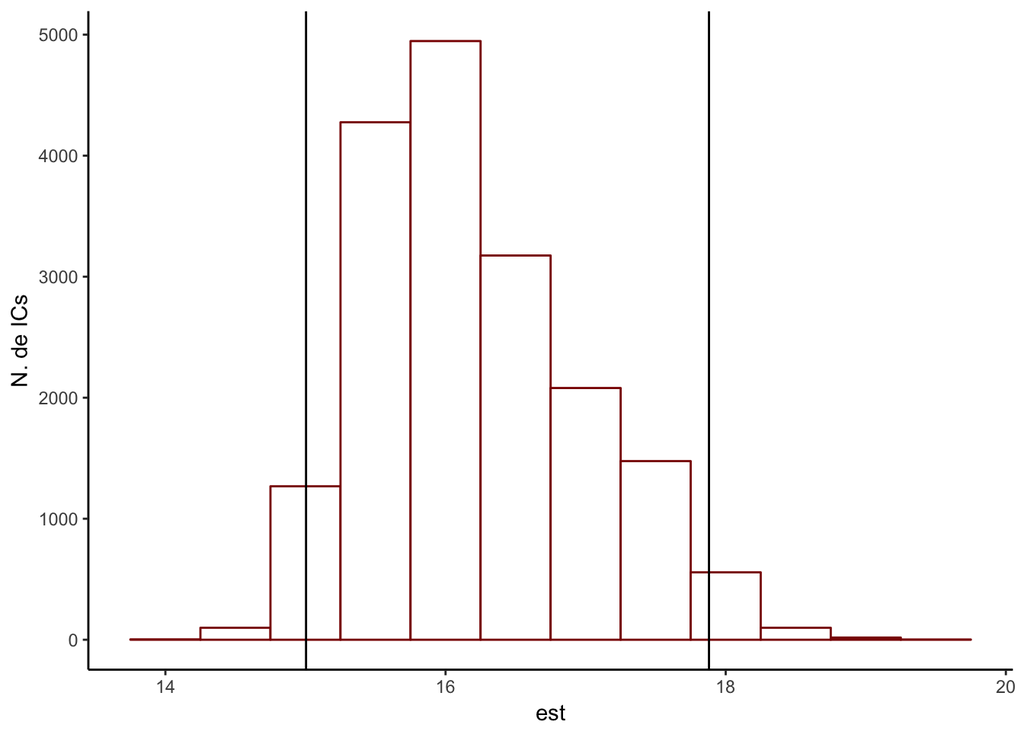

```r
diferencas = tibble(est = as.double(bootstraps_zero$t))

diferencas %>%
    ggplot(aes(x = est)) +
    geom_histogram(binwidth = 0.5, fill = "white", color = "darkred") +
  labs(y="N. de ICs") +
  geom_vline(xintercept = quantile(diferencas$est, 0.025)[[1]]) +
  geom_vline(xintercept = quantile(diferencas$est, 0.975)[[1]]) +
  theme_classic()
```

[output not shown]

O intervalo de confiaça da diferença foi positivo e apresentou um valor de 15.99% e 18.51%. Esses valores são praticamente o valor da média total. Agora verificaremos os ICs por todos os tipos:

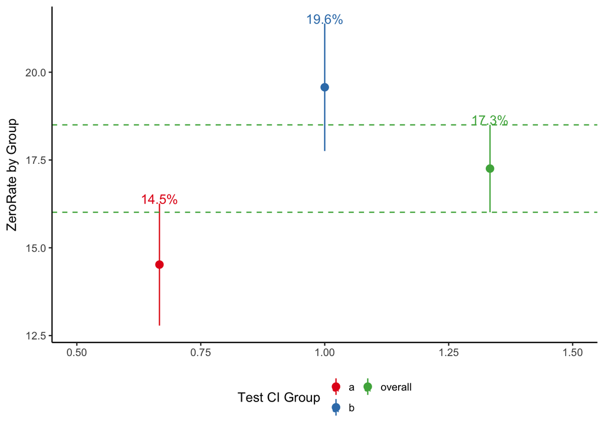

Analisando o gráfico dos intervalos de confiança por grupos, é possível verificar que existe uma diferença significativa dos zero resultados entre o grupo B do que no grupo A. Os intervalos de confiança para o grupo A foi entre 13.01% e 16.16%. Os intervalos de confiança para o grupo B foi entre 17.72 e 21.30.

Os ICs do grupo B são maiores que o grupo A, como tambem, um pouco maior que a média geral dos zero resultados. Assim, é possível concluir que o número de zero resultados é maior no grupo B, do que no grupo A. Relacionando com a taxa de cliques por pesquisa, podemos verificar que o grupo B apresentou uma taxa de cliques menor que o grupo A. Isso demonstra uma relação com os zero resultados da pesquisa, pois se o número de cliques é menor no grupo B, a principal causa pode ser a taxa de zero resultados apresentado no grupo B, o que resultaria em menos cliques.

**4. Testar o que acontece se para a pergunta 1, em vez de comparar o grupo A com o grupo B (um teste A/B), você compara metade das sessões do grupo A (escolhida aleatoriamente) com outra metade das sessões do mesmo grupo (um teste A/A).**

Primeiro é preciso selecionar os dados do grupo A, fazer as amostras aleatórias, para dois inferir os resultados:

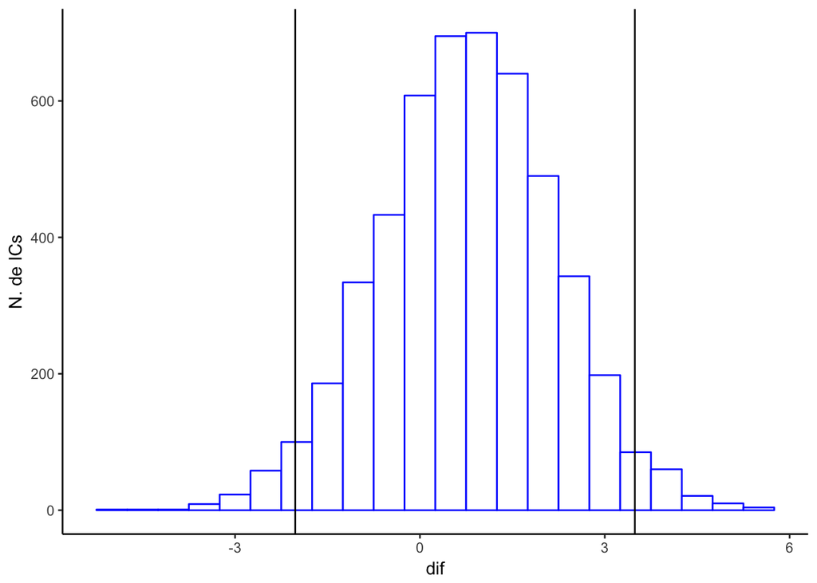

O gráfico acima apresenta o valor das diferenças dos boostraps, como também o seu valor máximo e mínimo. É possível verificar uma simetria nas diferenças, levando a inferir que não existe diferença significativa entre o grupo A e o grupo controlado A. O gráfico abaixo apresenta uma melhor visualização dessa relação:

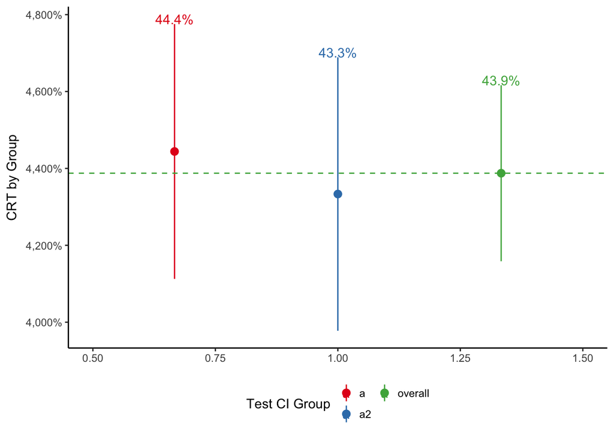

O grupo A e A2 apresentaram praticamente as mesmas médias do grupo total. Assim, a taxa de cliques para o grupo A, A2 e grupo total é relativamente igual durante todos os dias.

### 3) Conclusão

Após a exploração dos dados do Wimedia Foundation, verificamos a inferencia dos intervalos de confiança nas perguntas realizadas no [checkpoint 2](http://rpubs.com/aminueza/DiscoveryHiringAnalyst2016). Foram observadas que a taxa de cliques do Grupo A é significativamente maior que no grupo B. Correlacionando com a taxa de zero resultados, que é significativamente maior no grupo B, é possível verificar uma relação entre essas duas variáveis. Se um resultado não é apresentado, consequentemente ele terá uma taxa de cliques menor. Ao contrário do grupo A, que apresentou uma taxa de cliques maior e uma taxa de zero resultados menor. Verificando a taxa de cliques, foi possível verificar uma diferença significativa nos cliques a partir do primeiro resultado, ou seja, o primeiro resultado possui um número maior de cliques, seguido do segundo e terceiro resultados. O último teste, analisou a correlação dos testes A/A com a taxa de cliques. A partir dos intervalos de confiança foi possível verificar que a taxa de cliques do grupo A e do grupo controlado A2 são relativamente iguais a taxa de cliques geral para os dois grupos. Assim, é possível inferir que não há diferença significativa do CRT para as três variáveis.